# Nobel Prize Winners Analysis

Jonah Maroszek

2/16/2022

## Introduction

I chose to analyze data about Nobel Prize winners because I have always been interested in science. I thought it would be interesting to explore some characteristics of my scientific heroes. I used three data sets to help me answer some questions about Nobel Prize winners. They are named nobel, world, and country_codes in my code. nobel provides general data about the Nobel Prize winners, world is used to help create the map of the world which is used in the first visual, and country_codes is used to link these two data sets together.

### Load and Process Data

```r
nobel = read_csv("https://tinyurl.com/yctm5rz5", show_col_types = FALSE)

world = ne_countries(scale = "medium", returnclass = "sf")

country_codes = read_csv("https://tinyurl.com/y9lfy35w", show_col_types = FALSE) %>%
                select(c(starts_with("Alpha-2"), starts_with("English"))) %>%
                rename("birth_country" = "English short name lower case")

nobel_born_count = left_join(nobel, country_codes, by = c("born_country_code" = "Alpha-2 code")) %>%
                   left_join(world, by = c("birth_country" = "name")) %>%
                   group_by(born_country_code) %>%
                   summarize(nobel_born_count = n())

final_data = left_join(world, country_codes, by = c("name" = "birth_country")) %>%
             left_join(nobel_born_count, by = c("Alpha-2 code" = "born_country_code")) %>%
             select(c(name, nobel_born_count, pop_est, "Alpha-2 code")) %>%
             mutate(nobel_per_million = nobel_born_count / pop_est * 1000000)
```

### Where are most Nobel Prize winners born?

I have chosen the turbo color scheme because most other color schemes were very hard to discern the values between countries other than the United States.

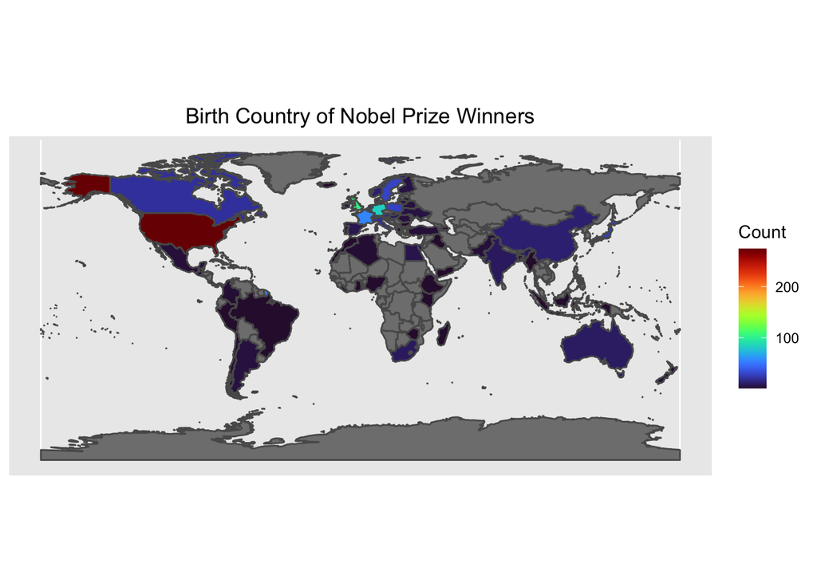

```r
ggplot(final_data, aes(fill = nobel_born_count)) +
  geom_sf() +
  ggtitle("Birth Country of Nobel Prize Winners") +
  labs(fill = "Count") +
  scale_fill_viridis(option="turbo") +
  theme(plot.title = element_text(hjust = 0.5))
```

```r
final_data %>%
  arrange(desc(nobel_born_count)) %>%
  select(c(name, nobel_born_count, nobel_per_million)) %>%
  tibble() %>%
  head(10)
```

| name | nobel_born_count | nobel_per_million | geometry |
| --- | --- | --- | --- |
| United States | 274 | 0.8726865 |  |
| United Kingdom | 103 | 1.6542996 |  |
| Germany | 82 | 0.9959947 |  |
| France | 56 | 0.8742106 |  |
| Sweden | 29 | 3.2010063 |  |
| Poland | 28 | 0.7275955 |  |
| Japan | 27 | 0.2124668 |  |
| Canada | 20 | 0.5972430 |  |
| Switzerland | 19 | 2.4985315 |  |
| Italy | 19 | 0.3268749 |  |

### What is the age distribution of Nobel Prize winners by birth month?

I was wondering if the age distribution would be different for any birth month for some reason. I thought a ridge plot would be a good way to compare the age distributions across all months. I added a median line for each distribution as well to make it easier to spot deviations from the norm. I also reordered the months chronologically.

I was surprised that February Nobel Prize winners seemed younger than the other months based on this visual. I conducted a t-test which revealed that February winners were indeed younger than the other months at a statistically significant level (one-sided t-test, p-value = .0002642).

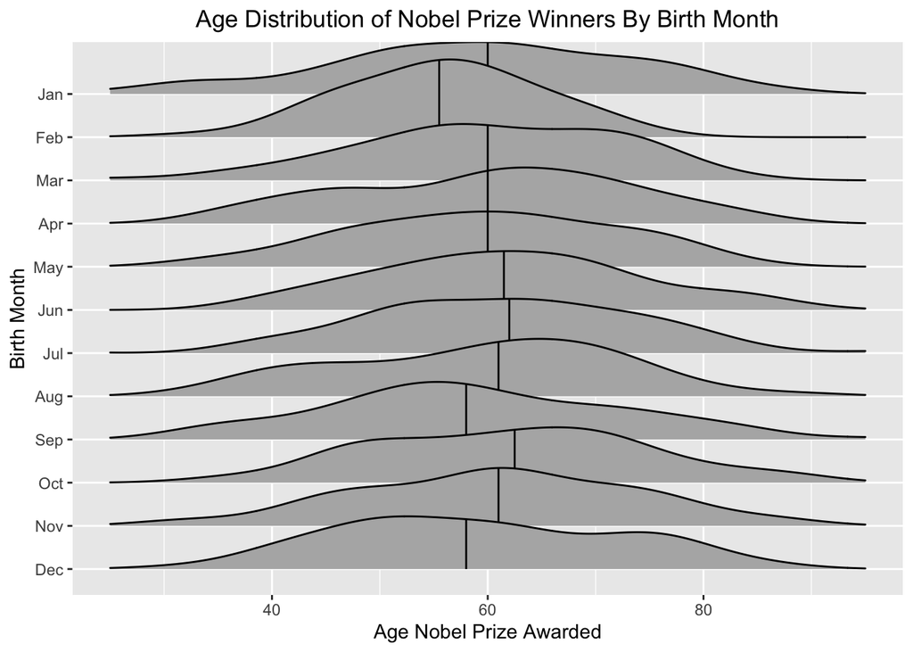

```r
ggplot(nobel, aes(x = age_get_prize, y = born_month)) +
  stat_density_ridges(from = 25, to = 95, quantile_lines = TRUE, quantiles = 2) +
  scale_y_discrete(limits = rev(month.abb)) +
  ylab("Birth Month") +
  xlab("Age Nobel Prize Awarded") +
  ggtitle("Age Distribution of Nobel Prize Winners By Birth Month") +
  theme(plot.title = element_text(hjust = 0.5))
```

```r
feb_winners = nobel %>% filter(born_month == "Feb")
all_others = nobel %>% filter(born_month != "Feb")

t_test = t.test(feb_winners$age_get_prize, all_others$age_get_prize, alternative = "less")
```